# FQ and R per card - Kline Dataset

Ruam Pimentel

3/11/2021

# Merging dataset

```r
# importing dataset
kline <- read_excel("Kline Protocols R-ID - All with Updated GM SCHB and EMS.xlsx") %>%
  rename(RID = `R-ID`)

jessa <- read_excel("Jessa Coded Responses - Kline Dataset 04-23-2020.xlsx") %>%
  mutate( ID = str_sub(CID, 2, 3) %>% as.numeric)

# merging
kline %<>% left_join(read_excel("Kline ID Key for Rorschach Protocols.xlsx") %>%
                       select(ID, RID))  %>%
  mutate(Card = as.roman(Cd) %>% as.numeric()) %>%
  rename( Rn = R) %>%
  left_join(jessa, by = c("ID", "Card", "Rn")) %>%
  select(ID, everything()) %>%
  arrange(ID, Card, Rn)
# FINAL DATA
data <- kline %>% select(ID, Card, Rn, FQ) %>%
  group_by(ID, Card) %>%
  mutate(Rn_card = 1:n()) %>%
  ungroup() %>%
  filter(!is.na(FQ), FQ != 9, Rn_card <= 4, FQ != 0) %>%
  mutate(FQ2 = case_when(FQ == 3 ~ 3,
                         FQ == 2 ~ 3,
                         FQ == 1 ~ 1))
data
```

```
## # A tibble: 1,321 x 6
##       ID  Card    Rn    FQ Rn_card   FQ2
##    <dbl> <dbl> <dbl> <dbl>   <int> <dbl>
##  1     1     1     1     3       1     3
##  2     1     1     2     3       2     3
##  3     1     1     3     1       3     1
##  4     1     2     4     2       1     3
##  5     1     2     5     2       2     3
##  6     1     3     6     3       1     3
##  7     1     3     7     3       2     3
##  8     1     4     8     3       1     3
##  9     1     4     9     1       2     1
## 10     1     5    10     3       1     3
## # ... with 1,311 more rows
```

I’ve created a new column in the dataset called `Rn_Card`. This new variable indicates what is the number of response per card. The count reset in each card. Take a look in the `data` dataframe below, also this dataframe only contains `ID`, `Card`, `Rn`, `FQ`, and `Rn_card`, which are the only important variables for this analysis:

| ID | Card | Rn | FQ | Rn_card | FQ2 |
| --- | --- | --- | --- | --- | --- |
| 1 | 1 | 1 | 3 | 1 | 3 |
| 1 | 1 | 2 | 3 | 2 | 3 |
| 1 | 1 | 3 | 1 | 3 | 1 |
| 1 | 2 | 4 | 2 | 1 | 3 |
| 1 | 2 | 5 | 2 | 2 | 3 |
| 1 | 3 | 6 | 3 | 1 | 3 |
| 1 | 3 | 7 | 3 | 2 | 3 |
| 1 | 4 | 8 | 3 | 1 | 3 |
| 1 | 4 | 9 | 1 | 2 | 1 |
| 1 | 5 | 10 | 3 | 1 | 3 |

[output cut: 1311 more lines]

## Analysis a

### FQ and Rn_Card counts

I’ve excluded cases with missing FQ, or cases where FQ == 9, which I’m not sure that that means. maybe typos?

| FQ | n |
| --- | --- |
| 1 | 211 |
| 2 | 432 |
| 3 | 678 |

| Rn_card | n |
| --- | --- |
| 1 | 665 |
| 2 | 412 |
| 3 | 175 |
| 4 | 69 |

**Should I run analysis just for `Rn_card <= 4`?**

Data summary

| Name | Piped data |
| --- | --- |
| Number of rows | 1321 |
| Number of columns | 6 |
| _______________________ |  |
| Column type frequency: |  |
| numeric | 5 |
| ________________________ |  |
| Group variables | None |

**Variable type: numeric**

| skim_variable | n_missing | complete_rate | mean | sd | p0 | p25 | p50 | p75 | p100 | hist | skewness | kurtosis |
| --- | --- | --- | --- | --- | --- | --- | --- | --- | --- | --- | --- | --- |
| Card | 0 | 1 | 5.32 | 3.03 | 1 | 3 | 5 | 8 | 10 | ▇▆▆▆▇ | 0.09 | -1.31 |
| Rn | 0 | 1 | 11.63 | 8.07 | 1 | 5 | 10 | 16 | 44 | ▇▆▂▁▁ | 1.06 | 1.29 |
| FQ | 0 | 1 | 2.35 | 0.74 | 1 | 2 | 3 | 3 | 3 | ▂▁▅▁▇ | -0.67 | -0.90 |
| Rn_card | 0 | 1 | 1.73 | 0.88 | 1 | 1 | 1 | 2 | 4 | ▇▅▁▂▁ | 1.01 | 0.12 |
| FQ2 | 0 | 1 | 2.68 | 0.73 | 1 | 3 | 3 | 3 | 3 | ▂▁▁▁▇ | -1.86 | 1.45 |

taking a look at the variables, all presented Skew <|2.0| and kurtosis <|6|, but the small histograms show clear skewed curves for FQ and Rn_card. with more people having better FQ, and more people having less responses per cards.

# Main Analysis

So the idea was to test whether FQ get worse as the response number increase. For instance, first response to a card would have a better FQ than the second response, which will be better then the third response, which will be better than the four response.

As an extreme scenario we are testing if we have cases like this:

- First response to a card -> FQo (3)
- Second response to a card -> Fqu (2)
- Third response to a card -> Fq- (1)
- Fourth response to a card -> Fqn (0)

given FQo == 3, FQu ==2, FQ- == 1, FQn == 0, we anticipate a negative correlation between the number of the response per card with FQ.

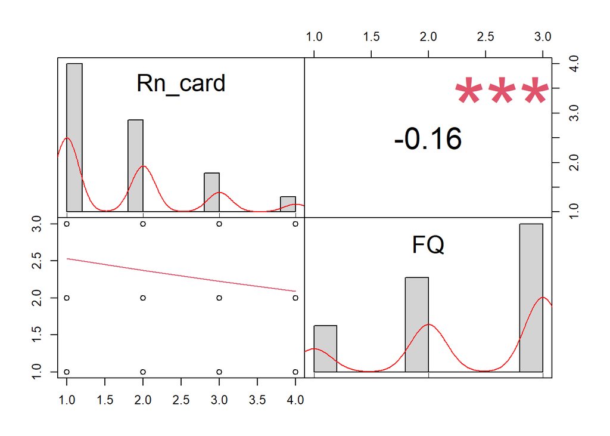

This is the result from Kline dataset, we observed a correlation with *r* = -.16, *p* < .001 , 95%CI[-.21, -.11]

From the scatterplot above, is hard to tell how the association really looks like, because most of the dots are on top of the others, so below, we can see a new scatterplot, presenting the same information as above but dispersing the dots a bit so we can better see the really amount of dots in each quadrant. The shadowy area around the regression line shows the CI.

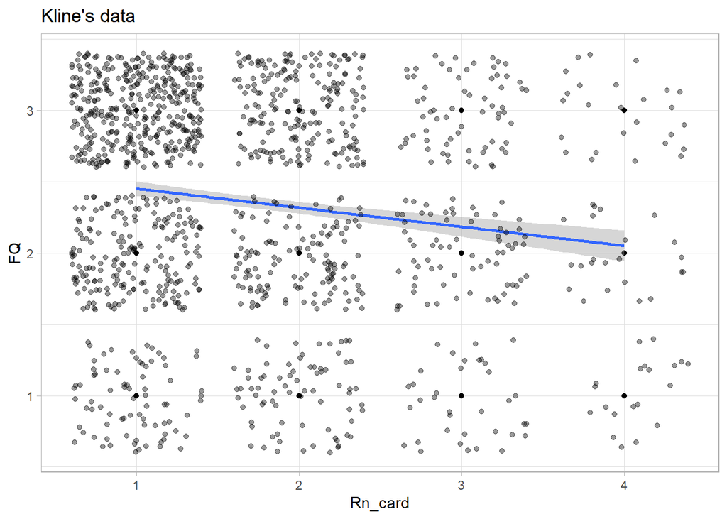

This way we can see that the association is indeed low. However, it is negative, which is in the expected direction.

After seeing the effect above, I got curious to see how would be these associations per card! In the graph below we can see the association between FQ per number of the response (Rn_card) per Card. Each graph represent the correlation in the specific Card. See below.

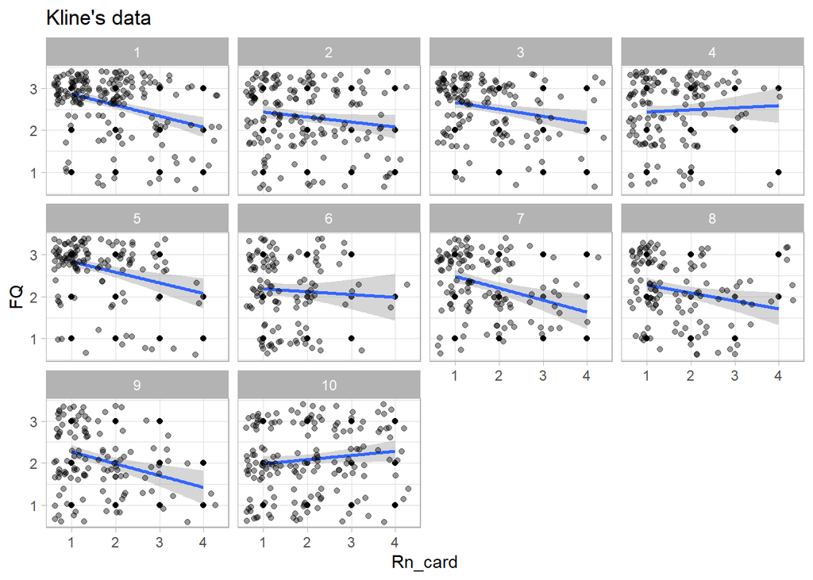

Being more precise, but still the same analysis per card, below we can see the strength of the association between FQ and Rn_card per card. In the y axis we see Pearson’s r. The error bars show CI. It seems that the biggest associations was found on **Card I** (*r* = -.36, *p* < .001, 95%CI [-.48, -.22]), followed by **Card IX** (*r* = -.32, *p* = .001, 95%CI [-.47, -.14]), and **Card V** (*r* = -.31, *p* = .001, 95%CI [-.47, -.14]). Followed by card IX which was very similar to Card VII

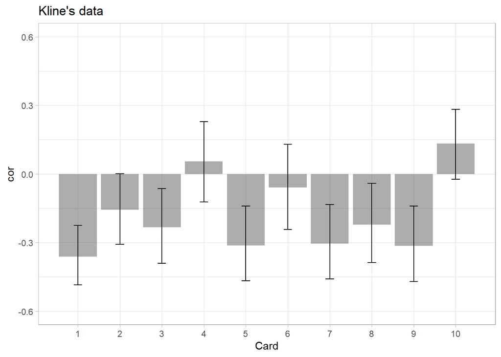

| Card | cor | CI_min | CI_max | p_value |
| --- | --- | --- | --- | --- |
| I | -0.36 | -0.48 | -0.22 | 0.00 |
| II | -0.16 | -0.31 | 0.00 | 0.05 |
| III | -0.23 | -0.39 | -0.06 | 0.01 |
| IV | 0.05 | -0.12 | 0.23 | 0.55 |
| V | -0.31 | -0.47 | -0.14 | 0.00 |
| VI | -0.06 | -0.24 | 0.13 | 0.54 |
| VII | -0.30 | -0.46 | -0.13 | 0.00 |
| VIII | -0.22 | -0.39 | -0.04 | 0.02 |
| IX | -0.32 | -0.47 | -0.14 | 0.00 |
| X | 0.13 | -0.02 | 0.28 | 0.10 |

# Filtering out FQu (FQ == u)

```r
data_filtered <- data %>% filter(FQ != 2)
```

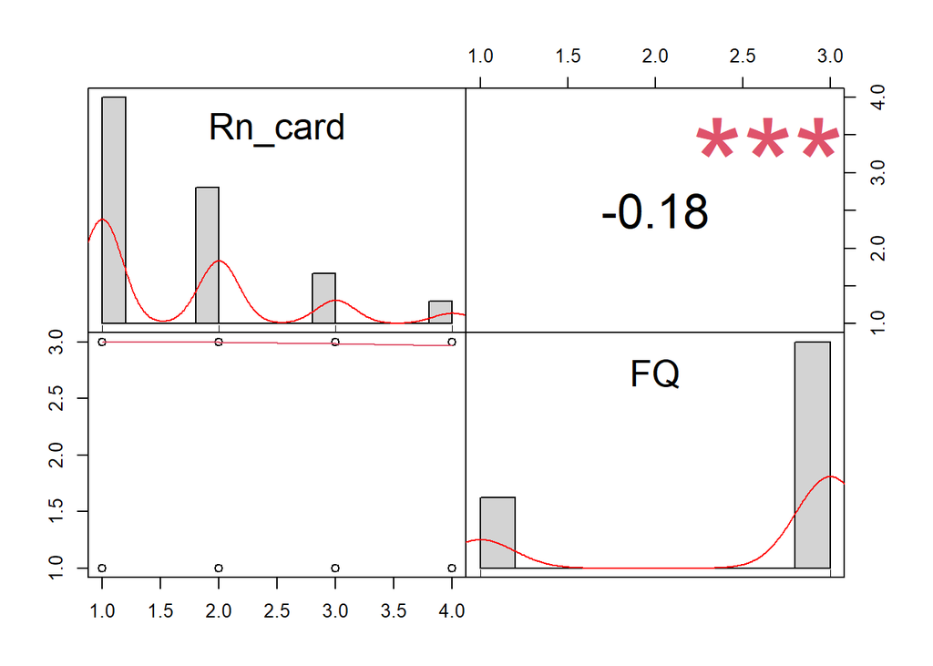

This is the result from Kline dataset, we observed a correlation with *r* = -.18, *p* < .001 , 95%CI[-.25, -.12]

From the scatterplot above, is hard to tell how the association really looks like, because most of the dots are on top of the others, so below, we can see a new scatterplot, presenting the same information as above but dispersing the dots a bit so we can better see the really amount of dots in each quadrant. The shadowy area around the regression line shows the CI.

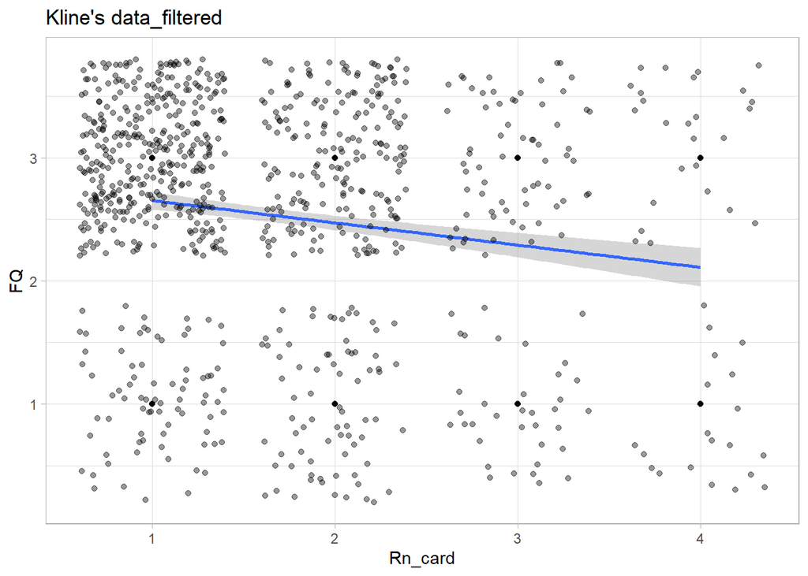

This way we can see that the association is indeed low. However, it is negative, which is in the expected direction.

After seeing the effect above, I got curious to see how would be these associations per card! In the graph below we can see the association between FQ per number of the response (Rn_card) per Card. Each graph represent the correlation in the specific Card. See below.

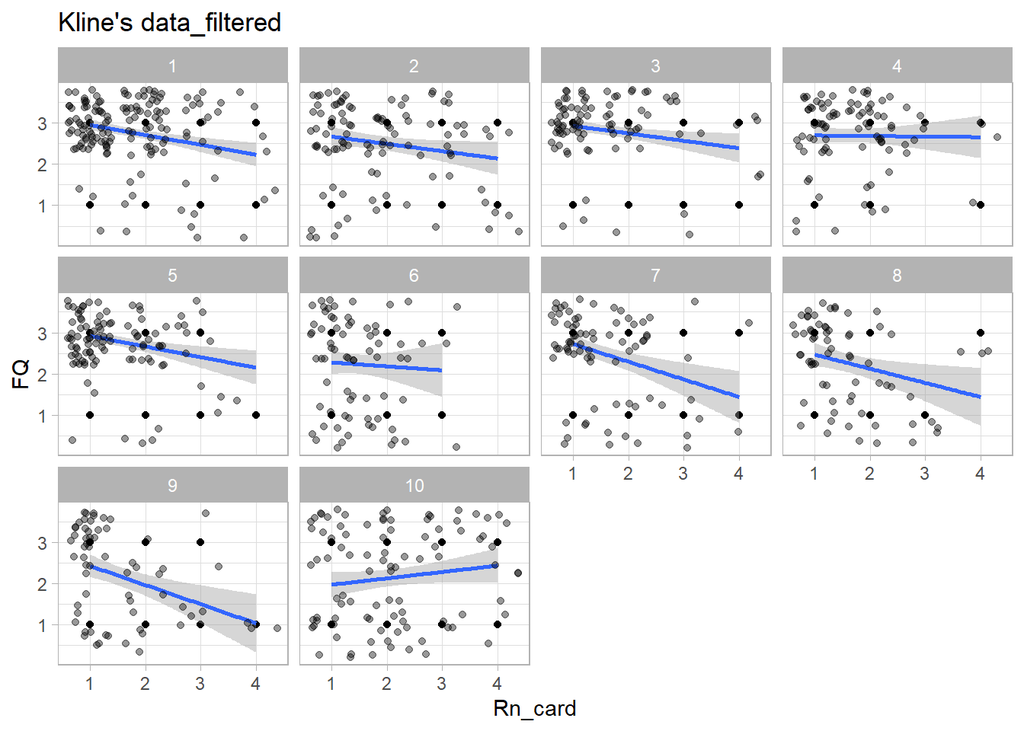

Being more precise, but still the same analysis per card, below we can see the strength of the association between FQ and Rn_card per card. In the y axis we see Pearson’s r. The error bars show CI. It seems that the biggest associations was found on **Card IX** (*r* = -.40, *p* < .001, 95%CI [-.59, -.17]), followed by **Card VII** (*r* = -.37, *p* = .001, 95%CI [-.55, -.16]), and **Card I** (*r* = -.32, *p* < .001, 95%CI [-.46, -.16]). Followed by card IX which was very similar to Card VII

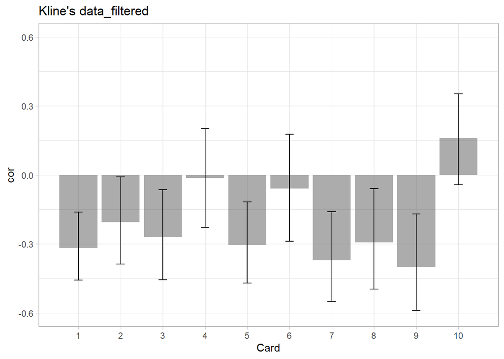

| Card | cor | CI_min | CI_max | p_value |
| --- | --- | --- | --- | --- |
| I | -0.32 | -0.46 | -0.16 | 0.00 |
| II | -0.21 | -0.39 | -0.01 | 0.04 |
| III | -0.27 | -0.46 | -0.06 | 0.01 |
| IV | -0.01 | -0.23 | 0.20 | 0.90 |
| V | -0.30 | -0.47 | -0.12 | 0.00 |
| VI | -0.06 | -0.29 | 0.18 | 0.63 |
| VII | -0.37 | -0.55 | -0.16 | 0.00 |
| VIII | -0.29 | -0.50 | -0.06 | 0.02 |
| IX | -0.40 | -0.59 | -0.17 | 0.00 |
| X | 0.16 | -0.04 | 0.35 | 0.12 |

# using FQ2 (FQo and FQu == 3, FQ- == 1)

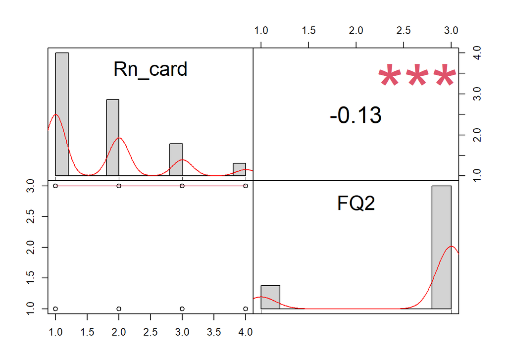

From the scatterplot above, is hard to tell how the association really looks like, because most of the dots are on top of the others, so below, we can see a new scatterplot, presenting the same information as above but dispersing the dots a bit so we can better see the really amount of dots in each quadrant. The shadowy area around the regression line shows the CI.

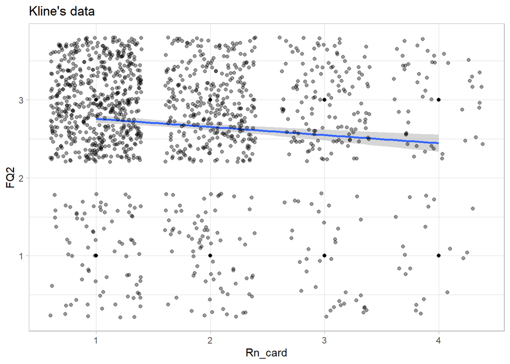

This way we can see that the association is indeed low. However, it is negative, which is in the expected direction.

After seeing the effect above, I got curious to see how would be these associations per card! In the graph below we can see the association between FQ2 per number of the response (Rn_card) per Card. Each graph represent the correlation in the specific Card. See below.

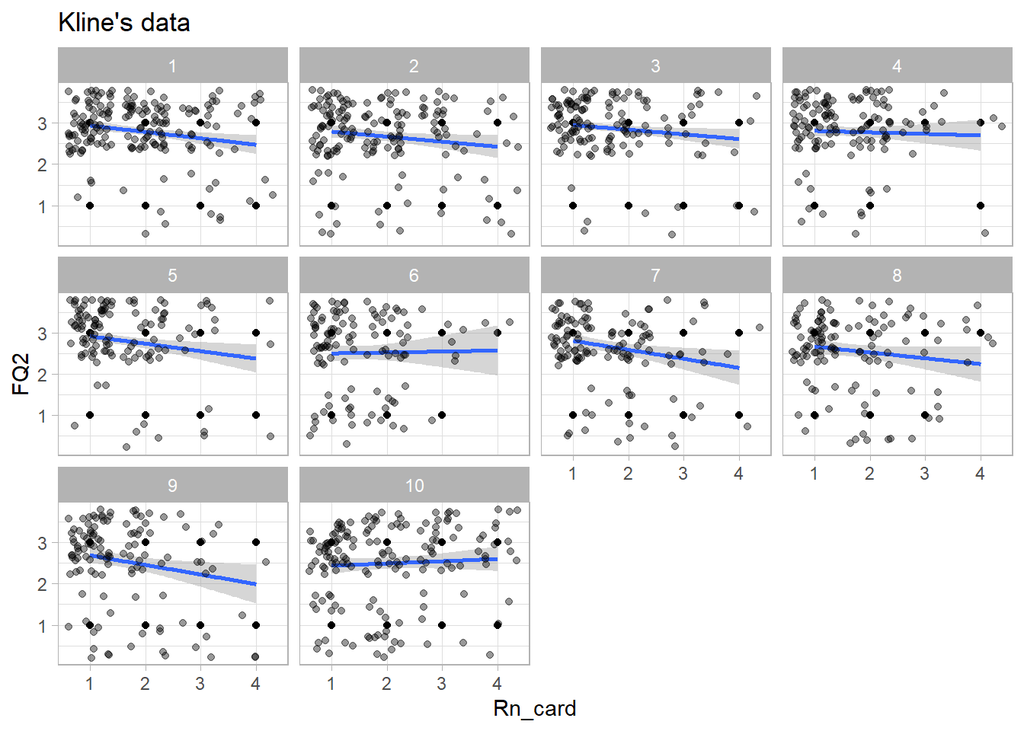

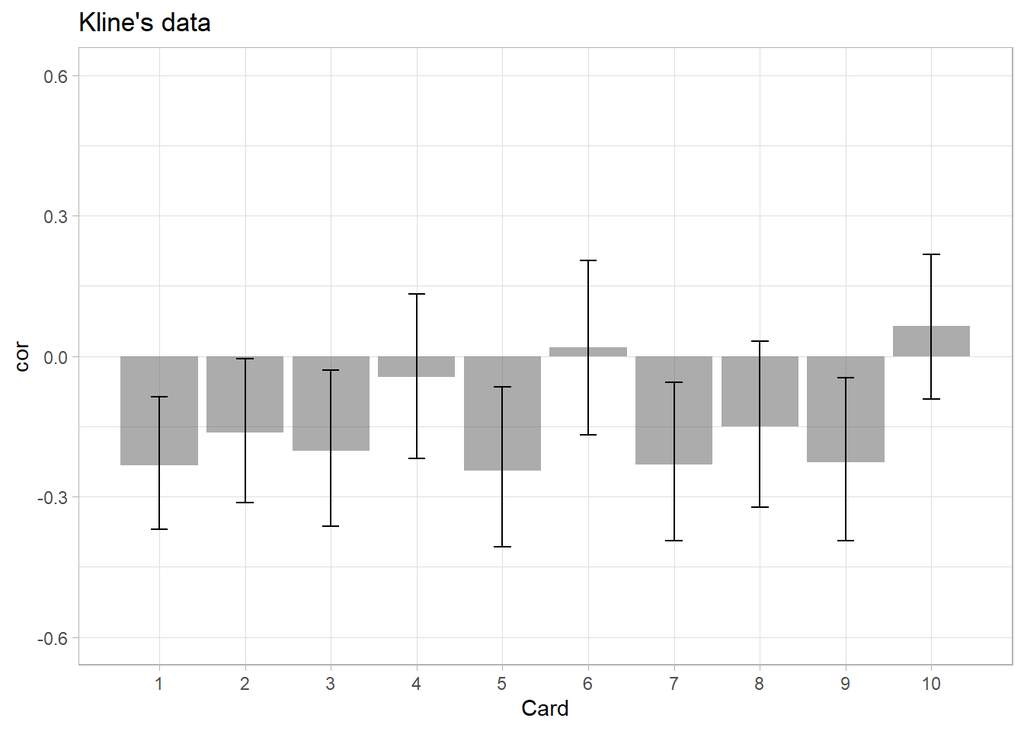

| Card | cor | CI_min | CI_max | p_value |
| --- | --- | --- | --- | --- |
| I | -0.23 | -0.37 | -0.09 | 0.00 |
| II | -0.16 | -0.31 | -0.01 | 0.04 |
| III | -0.20 | -0.36 | -0.03 | 0.02 |
| IV | -0.04 | -0.22 | 0.13 | 0.63 |
| V | -0.24 | -0.41 | -0.07 | 0.01 |
| VI | 0.02 | -0.17 | 0.20 | 0.85 |
| VII | -0.23 | -0.39 | -0.06 | 0.01 |
| VIII | -0.15 | -0.32 | 0.03 | 0.11 |
| IX | -0.23 | -0.39 | -0.05 | 0.01 |
| X | 0.06 | -0.09 | 0.22 | 0.42 |